# Survival analysis

## Objectives

We aim to introduce you to the basic R functionality and R packages for analysing survival data. We will use the following:

- Kaplan-Meier plots - to visualize survival curves
- Log-rank test - to compare the survival of two or more groups
- Cox proportional hazards regression - to describe the effect of variables on survival.

## Basics of survival data

### Censoring

Survival analysis deals with duration of time until an event (death, myocardial infarction, surgery). However, if the event is not occuring within the observed timeframe of the study period, the patients are registred as censored observations.

Censoring may arise in the following ways:

- a patient has not (yet) experienced the event of interest, such as death, within the study time period;
- a patient is lost to follow-up during the study period;
- a patient experiences a different event that makes further follow-up impossible. This type of censoring, named right censoring, is handled in survival analysis.

### Survival and hazard functions

Survival probability and hazard probability are two related probabilities used to describe survival data.

- Survival probability:
- the probability that an individual survives from the time origin to a specified future time.
- Hazard
- the probability that an individual who is under observation at a time has an event at that time.

## Install and load required R package

We will use two new R packages for this case study.

**survival** for computing survival analyses **survminer** for summarizing and visualizing the results of survival analysis

```r
install.packages("survival")
install.packages("survminer")
```

```r
library(readxl)  # Reading Excel files.
library(tibble)  # The "tibble" datastructure.
library(dplyr)  # Working with the tibble datastructure.
library(ggplot2)  # Plotting.
library(lubridate)  # Working with datetime objects.
library(magrittr)  # Need this for the %>% operator.
library(devtools)  # For printing the session info at the end of the notebook.
library(survival)
library(survminer)
library(tidytidbits)
library(survivalAnalysis)
library(ranger)
library(ggfortify)
library(broom)
```

## Loading a dataset

We will use data from patients with primary biliary cirrohosis (PBC) that was randomized for treatment with ursodeoxycholic acid (UDCA).

The data is part of the package “survival” as illustrative data.

> References T. M. Therneau and P. M. Grambsch, Modeling survival data: extending the Cox model. Springer, 2000. K. D. Lindor, E. R. Dickson, W. P Baldus, R.A. Jorgensen, J. Ludwig, P. A. Murtaugh, J. M. Harrison, R. H. Weisner, M. L. Anderson, S. M. Lange, G. LeSage, S. S. Rossi and A. F. Hofman. Ursodeoxycholic acid in the treatment of primary biliary cirrhosis. Gastroenterology, 106:1284- 1290, 1994.

```r
data(udca)
```

This will load three different data sets (udca, udca1 and udca2). udca is the most basic data. udca1 contains all the baseline variables and variables describing time until the first endpoints. We will use udca1.

## checking the variables and data formats

```r
head(udca1)
```

```
##   id trt stage bili riskscore futime status
## 1  1   1     1  1.0       5.1   1896      0
## 2  2   0     1  1.7       4.2   1456      1
## 3  3   1     0  0.5       3.4   1892      0
## 4  4   1     1  1.4       5.0    343      0
## 5  5   0     1  1.1       4.3   1875      0
## 6  6   1     1  1.4       5.9    768      1
```

**id** subject identifier **trt** treatment of 0=placebo, 1=UDCA **entry.dt** date of entry into the study **last.dt** date of last on-study visit **stage** stage of disease **bili** bilirubin value at entry **riskscore** the Mayo PBC risk score at entry death.dt date of death **tx.dt** date of liver transplant **hprogress.dt** date of histologic progression varices.dt appearance of esphogeal varices ascites.dt appearance of ascites **enceph.dt** appearance of encephalopathy double.dt doubling of initial bilirubin worsen.dt worsening of symptoms by two stages

## Kaplan-Meier survival curve

The Kaplan-Meier is a non-parametric method used to estimate the survival probability from observed survival times (Kaplan and Meier, 1958).

We will use the survfit function to calculate survival times and load them in “fit”.

```r
fit <- survfit(Surv(futime, status)
               ~ trt, data = udca1)
print(fit)
```

```
## Call: survfit(formula = Surv(futime, status) ~ trt, data = udca1)
##
##        n events median 0.95LCL 0.95UCL
## trt=0 84     45    992     768      NA
## trt=1 86     27     NA    1508      NA
```

survfit is a function from the survival package that contains the core survival analysis Surv difines the survival objects. trt is not an obligatory input, however because we want to see the data stratified by treatment we will use it.

To display the full survival table type:

```r
summary(fit)
```

```
## Call: survfit(formula = Surv(futime, status) ~ trt, data = udca1)
##
##                 trt=0
##  time n.risk n.event survival std.err lower 95% CI upper 95% CI
##    47     83       1    0.988  0.0120        0.965        1.000
##   189     81       1    0.976  0.0169        0.943        1.000
##   272     78       1    0.963  0.0208        0.923        1.000
##   340     76       1    0.951  0.0241        0.904        0.999
##   351     75       1    0.938  0.0269        0.887        0.992
##   362     74       1    0.925  0.0294        0.869        0.985
##   364     73       1    0.913  0.0316        0.853        0.977
##   370     72       1    0.900  0.0336        0.836        0.968
##   375     71       1    0.887  0.0354        0.820        0.959
##   377     70       1    0.875  0.0371        0.805        0.950
##   383     69       1    0.862  0.0387        0.789        0.941
```

[output cut: 63 more lines]

And to display a summary text, type:

```r
summary(fit)$table
```

```
##       records n.max n.start events   *rmean *se(rmean) median 0.95LCL
## trt=0      84    84      84     45 1154.652   71.87860    992     768
## trt=1      86    86      86     27 1509.986   60.06917     NA    1508
##       0.95UCL
## trt=0      NA
## trt=1      NA
```

We will now use the function ggsurvplot (from the **survminer** package) to produce the kaplan meier survival curves for the two groups of subjects.

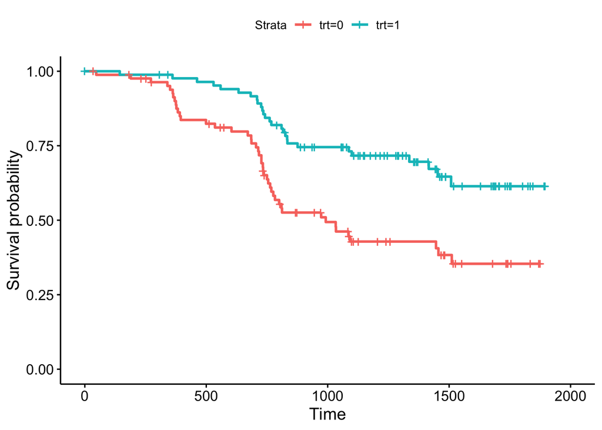

```r
ggsurvplot(fit)
```

This is a rough draft and it is now possible to finetune the plot. - Add the 95% confidence limits using the argument **conf.int** = TRUE. - Add the number at risk by time using the **risk.table.** = TRUE - Add the p-value of the Log-Rank test using **pval** = TRUE. - Add lines at median survival using **surv.median.line.** = c(“none”, “hv”, “h”, “v”)

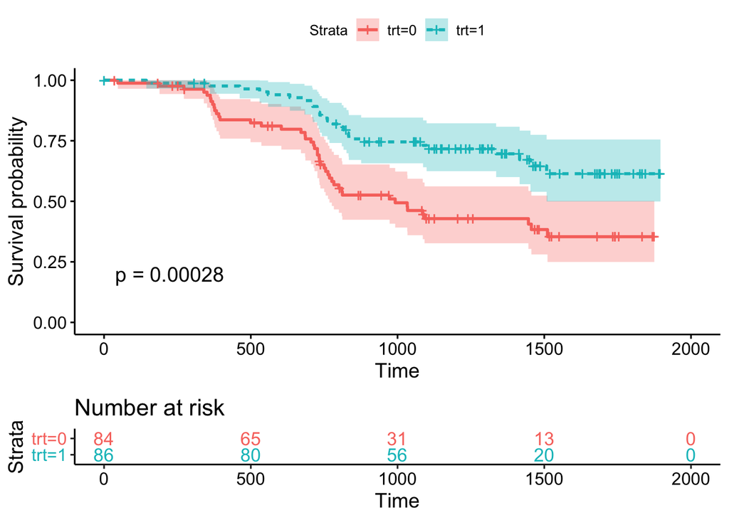

```r
ggsurvplot(fit,
          pval = TRUE, # p-value of the Log-Rank test
          conf.int = TRUE, # 95% confidence limits
          risk.table = TRUE, # Add risk table of patients at risk to the specified times
          risk.table.col = "strata", # Change risk table color by groups
          linetype = "strata", # Change line type by groups
          surv.median.line = "none", # Specify median survival
          )
```

We will try to change a few more settings:

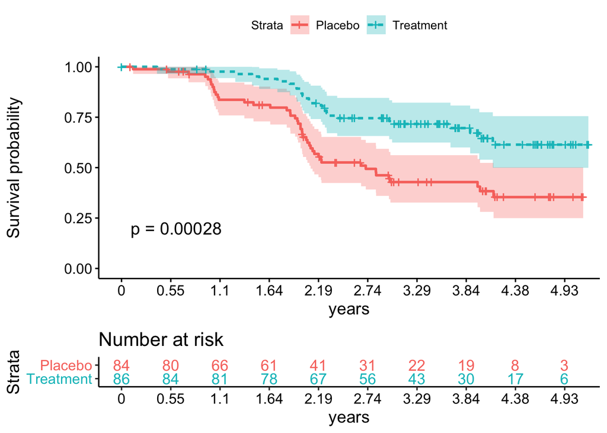

```r
ggsurvplot(fit,
  pval = TRUE, # p-value of the Log-Rank test
  conf.int = TRUE, # 95% confidence limits
  risk.table = TRUE, # Add risk table of patients at risk to the specified times
  risk.table.col = "strata", # Change risk table color by groups
  linetype = "strata", # Change line type by groups
  surv.median.line = "none", # Specify median survival
  break.time.by = 200, # break x axis in time intervals by 200.
  legend.labs = c("Placebo", "Treatment"), # to change the legend labels
  xlab="years", # change axis label
  xscale=365, # Divide the x-axis scale by a number
  xlim=c(0,1850) # Change axis limits
)
```

To change the groups we need to change the function:

```r
fit <- survfit(Surv(futime, status) ~ stage, data = udca1)
```

Remember to change legends, but the rest of the function can be reused:

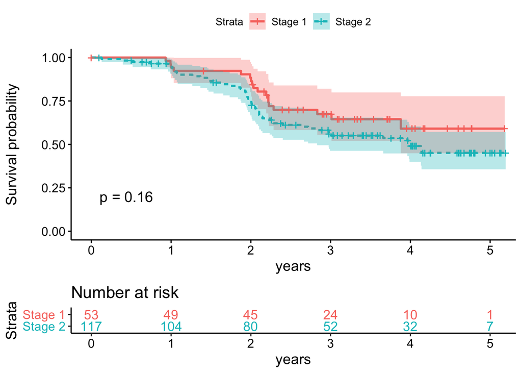

```r
ggsurvplot(fit,
pval = TRUE, # p-value of the Log-Rank test
conf.int = TRUE, # 95% confidence limits
risk.table = TRUE, # Add risk table of patients at risk to the specified times
risk.table.col = "strata", # Change risk table color by groups
linetype = "strata", # Change line type by groups
surv.median.line = "none", # Specify median survival
break.time.by = 365, # break x axis in time intervals by 200.
legend.labs = c("Stage 1", "Stage 2"), # to change the legend labels
xlab="years",
xscale=365,
xlim=c(0,1850)
)
```

## Log-Rank test comparing survival curves

The log-rank test is the most widely used method of comparing two or more survival curves. The null hypothesis is that there is no difference in survival between the two groups. The log rank test is a non-parametric test, which makes no assumptions about the survival distributions.

```r
surv_diff <- survdiff(Surv(futime, status) ~ trt, data = udca1)
surv_diff
```

```
## Call:
## survdiff(formula = Surv(futime, status) ~ trt, data = udca1)
##
##        N Observed Expected (O-E)^2/E (O-E)^2/V
## trt=0 84       45     29.9      7.68      13.2
## trt=1 86       27     42.1      5.44      13.2
##
##  Chisq= 13.2  on 1 degrees of freedom, p= 3e-04
```

n: the number of subjects in each group. obs: the weighted observed number of events in each group. exp: the weighted expected number of events in each group. chisq: the chisquare statistic for a test of equality.

## Cox regression analysis

```r
fit1 <- coxph(Surv(futime, status) ~ trt + log(bili) + stage, data=udca1)

tidy(fit1)
```

```
## # A tibble: 3 x 7
##   term      estimate std.error statistic   p.value conf.low conf.high
##   <chr>        <dbl>     <dbl>     <dbl>     <dbl>    <dbl>     <dbl>
## 1 trt        -1.03       0.255    -4.03  0.0000561   -1.53     -0.528
## 2 log(bili)   0.622      0.151     4.13  0.0000370    0.327     0.918
## 3 stage      -0.0665     0.290    -0.229 0.819       -0.636     0.503
```

A cox proportional hazards model assumes a baseline hazard function, i.e. the hazard for the reference group. Each predictor has a multiplicative effect on the hazard.

The major assumption of the Cox model is that the hazard ratio for a predictor (Zi) is constant (eβi) and does not depend on the time, i.e. the hazards in the two groups are proportional over time.

We can check whether the data are sufficiently consistent with the assumption of proportional hazards with respect to each of the variables separately as well as globally, using the **cox.zph()** function.

```r
cox.zph.fit1 <- cox.zph(fit1)
cox.zph.fit1
```

```
##                rho   chisq     p
## trt        0.09847 0.76290 0.382
## log(bili) -0.09736 0.65980 0.417
## stage     -0.00497 0.00176 0.967
## GLOBAL          NA 1.28916 0.732
```

No evidence against proportionality assumption could apparently be found.

It is possible to analyze these effects further with other packages: **ggcoxzph** and for diagnostic **ggcoxdiagnostics**.

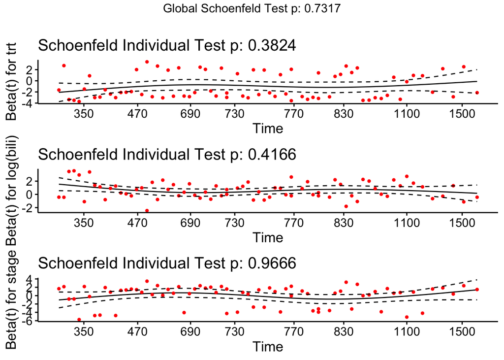

```r
ggcoxzph(cox.zph.fit1)
```

## Forrest plots

A good way to display and compare the hazard ratios from the cox regression model is a forrest plot.

The forrest plot can be displayed with a simple code from the ggplot package:

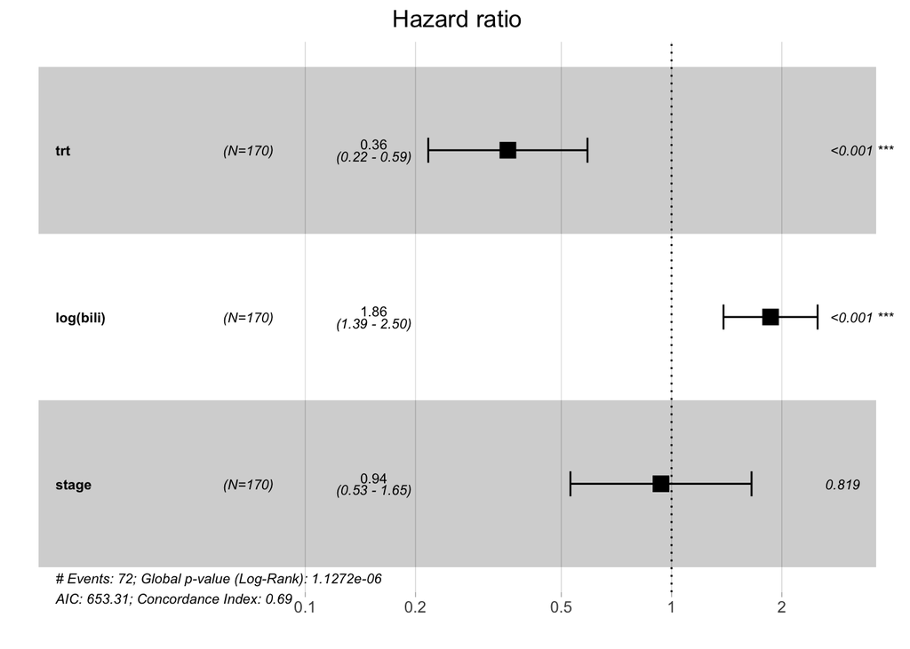

```r
ggforest(fit1)
```

However, this plot can be changed a bit. Lets consider stage as a categorical factor instead of as a numerical:

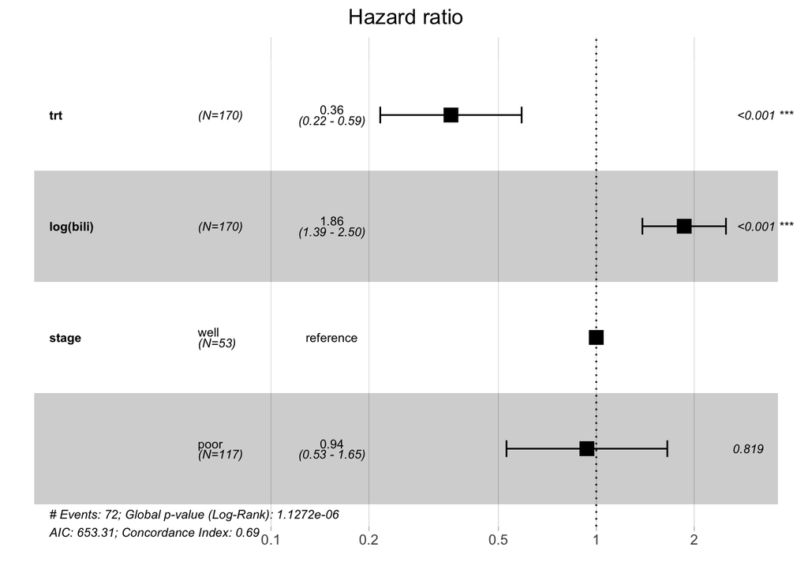

```r
udca1 <- within(udca1,
                {stage <- factor(stage, labels = c("well", "poor"))
                })

fit1 <- coxph(Surv(futime, status) ~ trt + log(bili) + stage
              , data=udca1)

ggforest(fit1)
```

We can do a little bit more by adding a tittle, changing the font size, changing the positions of the text.

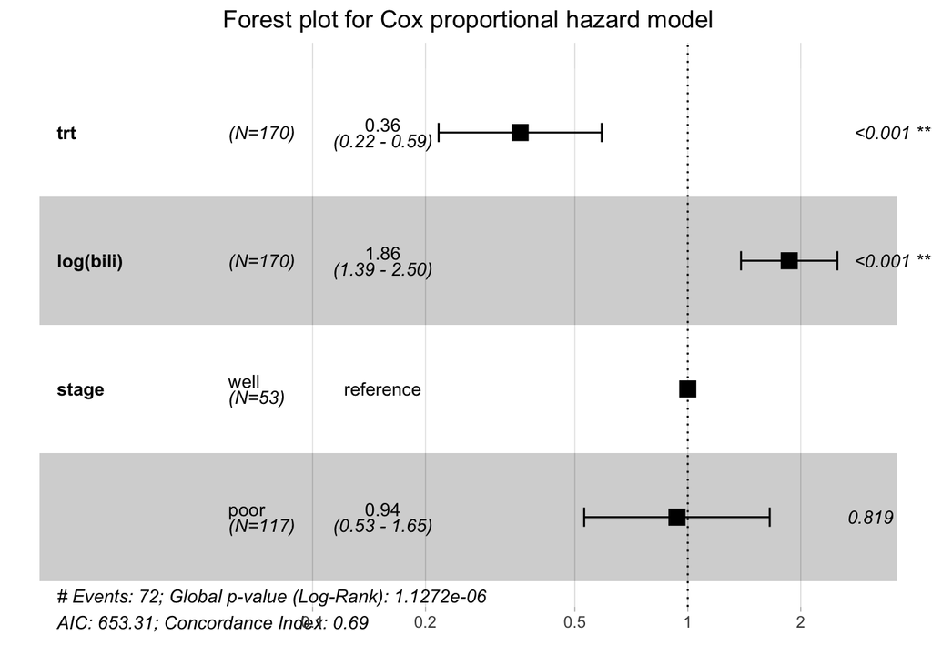

```r
ggforest(fit1, main="Forest plot for Cox proportional hazard model", fontsize=0.9, cpositions = c(0.02, 0.22, 0.4), noDigits = 2)
```